# Modelling Online Collaborative Mathematics

### Patrick Allo

#### Oxford Internet Institute

# The Polymath Projects

### *I’m interested in the question of whether it is possible for lots of people to solve one single problem rather than lots of people to solve one problem each*

#### Timothy Gowers “Is massively collaborative mathematics possible?”

It seems to me that, at least in theory, a different model could work: different, that is, from the usual model of people working in isolation or collaborating with one or two others. Suppose one had a forum (in the non-technical sense, but quite possibly in the technical sense as well) for the online discussion of a particular problem. The idea would be that anybody who had anything whatsoever to say about the problem could chip in. And the ethos of the forum -- in whatever form it took -- would be that **comments would mostly be kept short.** In other words, **what you would not tend to do, at least if you wanted to keep within the spirit of things, is spend a month thinking hard about the problem and then come back and write ten pages about it**. Rather, you would contribute ideas even if they were undeveloped and/or likely to be wrong.

Here is where the beauty of blogs, wikis, forums etc. comes in: they are completely public, as is their entire history. To see what effect this might have, imagine that a problem was being solved via comments on a blog post. Suppose that the blog was pretty active and that the post was getting several interesting comments. And suppose that you had an idea that you thought might be a good one. Instead of the usual reaction of being afraid to share it in case someone else beat you to the solution, you would be afraid not to share it in case someone beat you to that particular idea. **And if the problem eventually got solved, and published under some pseudonym like Polymath, say, with a footnote linking to the blog and explaining how the problem had been solved, then anybody could go to the blog and look at all the comments. And there they would find your idea and would know precisely what you had contributed.** There might be arguments about which ideas had proved to be most important to the solution, but at least all the evidence would be there for everybody to look at.

# Why Polymath, again?

### We know more now

- More projects too investigate
- We understand the broader context of science online better

### But also plenty we do not yet know

- Is it really a different kind of mathematics?
- How valuable is this for the philosophy of mathematical practices?
- What's special about the social epistemology of mathematics?
- How does it actually work?

## Disciplinary perspective

- **Scientific practices:** e-science, crowd-science & citizen science *vs* mathematical practices
- **Social-informational patterns:** Between social networks and logics of information and collaboration.

# The projects

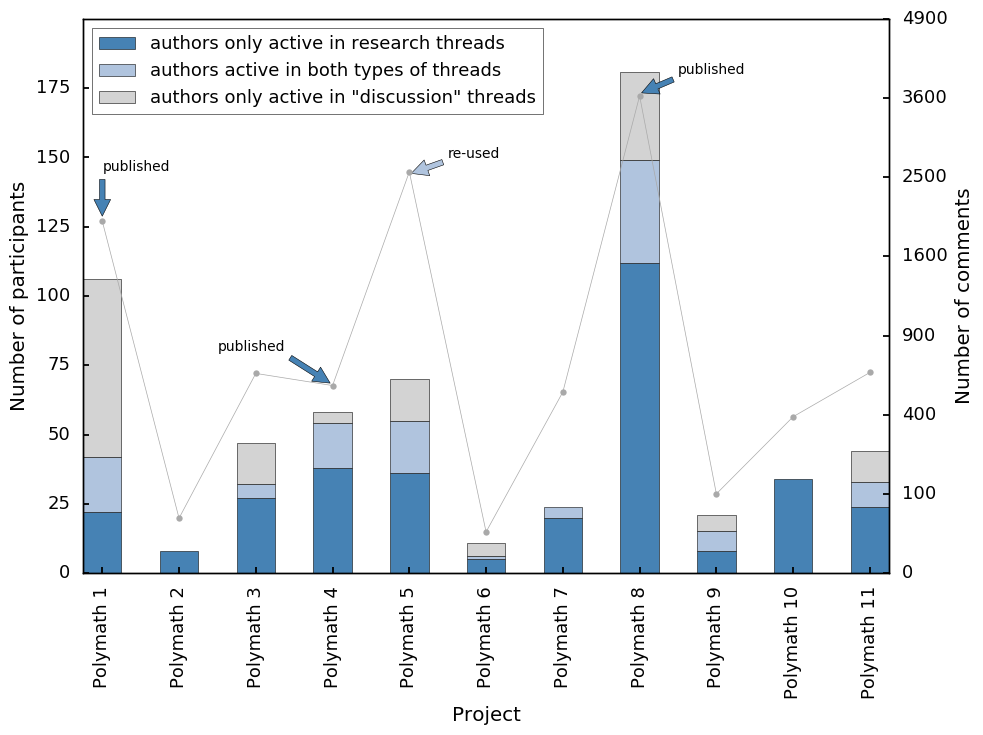

```python
# create overview-plot for all projects
matplotlib.style.use(SBSTYLE)
axes = plt.subplot()
AUTHOR_DATA.plot(kind='bar', stacked=True, color=['steelblue', 'lightsteelblue', 'lightgrey'], ax=axes)
#,title="Overview of all projects")
axes.xaxis.set_ticks_position('bottom')
axes.set_ylabel("Number of participants")
axes.set_ylim(0,200)
axes.set_yticks(range(0,200,25))
axes.annotate('published', xy=(0, 128), xytext=(0, 145),
            arrowprops=dict(facecolor='steelblue', shrink=0.05),
            )
axes.annotate('published', xy=(3, 68), xytext=(1.5, 80),
            arrowprops=dict(facecolor='steelblue', shrink=0.05),
            )
axes.annotate('re-used', xy=(4, 144), xytext=(4.5, 150),
            arrowprops=dict(facecolor='lightsteelblue', shrink=0.05),
            )
axes.annotate('published', xy=(7, 173), xytext=(7.5, 180),
            arrowprops=dict(facecolor='steelblue', shrink=0.05),
            )
COMMENT_DATA = np.sqrt(COMMENT_DATA)
axes2 = axes.twinx()
axes2.yaxis.set_major_formatter(FuncFormatter(lambda x, pos:"{:0.0f}".format(np.square(x))))
axes2.set_ylabel("Number of comments")
_ = axes2.plot(axes.get_xticks(), COMMENT_DATA.values,
                   linestyle='-', marker='.', linewidth=.5,
                   color='darkgrey')
plt.savefig("FIGS/overview_bar.png")
```

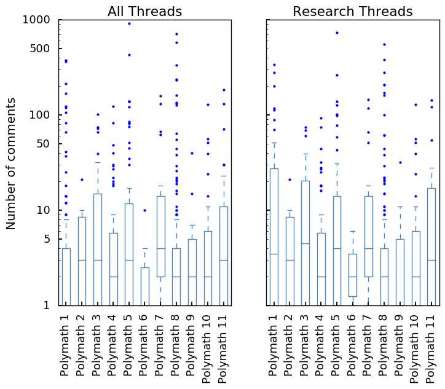

```python
# create box-plot of commenting-activity
commenting_author_project_r = get_last("research threads")[0]['research threads', 'comment_counter (accumulated)']
commenting_author_project_r.index = commenting_author_project_r.index.droplevel(1)
commenting_author_project_a = get_last("all threads")[0]['all threads', 'comment_counter (accumulated)']
commenting_author_project_a.index = commenting_author_project_a.index.droplevel(1)
commenting_author_project_r = commenting_author_project_r.apply(Series).T
commenting_author_project_a = commenting_author_project_a.apply(Series).T
fig, axes = plt.subplots(1,2, figsize=(8,6))
commenting_author_project_a.apply(Series).plot(kind='box', ax=axes[0],
                                               grid=False, logy=True, sym='.',
                                               rot=90, return_type='axes',
                                               color='steelblue',
                                               title = "All Threads")
axes[0].yaxis.set_major_formatter(ScalarFormatter())
axes[0].yaxis.set_ticks([1, 5, 10, 50, 100, 500, 1000])
axes[0].yaxis.set_ticklabels([1, 5, 10, 50, 100, 500, 1000])
axes[0].set_ylabel("Number of comments")
commenting_author_project_r.apply(Series).plot(kind='box', ax=axes[1],
                                               grid=False, logy=True, sym='.',
                                               rot=90, return_type='axes',
                                               color='steelblue',
                                               title = "Research Threads");
axes[1].yaxis.set_ticklabels([]);
for i in range(2):
    axes[i].xaxis.set_ticks_position('bottom')
    axes[i].yaxis.set_ticks_position('left')
plt.savefig("FIGS/overview_box.png")
```

# Polymath in Context

## “Massive collaboration”, but only because it's mathematics

- 7 years, 11 projects (and 3 mini-projects), and 465 distinct participants.
- Contrast: 7 Zooniverse-projects reached between 3,186 and 28,828 participants in their first 180 days (Sauermann and Franzoni 2015).
- Typical collaboration in mathematics is “small” (Grossman 2002).

## Online, but low-tech

- Off-the-shelf tools like WordPress and Wiki-software.
- Only the availability of a LaTeX-plugin was essential to the start of the project.
- Polymath is a re-usable format, but not a re-usable tool or platform.

## More open than other forms of crowd-science

- All contributions are visible.
- But not everyone can be a mathematician.
- Yet: focus on “elementary methods”.

## Less structured, but more interactive

- No well-defined sub-tasks and division of labour.
- No centralised aggregation.
- No hard-coded error-correction.
- Information doesn't only flow from nodes to central hub.
- Aggregation and error-correction is itself distributed and interactive.
- Harder to understand as reliable epistemic procedures.

# The Social Epistemology of Polymath

- Polymath as a scientific community:
  - More interactive
  - Crowd-sourcing the right community
  - Crowd-sourcing the research-agenda
- Polymath as an interactive aggregation procedure
- Unfinished epistemic products (typology of comments in Pease and Martin 2012)

## The problem of “keeping track of the common-ground”

- What is accepted, known failures, what is to be done
- Discussion-threads are limited to 100 comments, and blog-posts with an extensive summary initiate a new thread
- Common ground throughout a thread remains implicit.

### Maintaining and keeping track of the common ground is essential, but in principle very hard

# Polymath as a Scientific Community

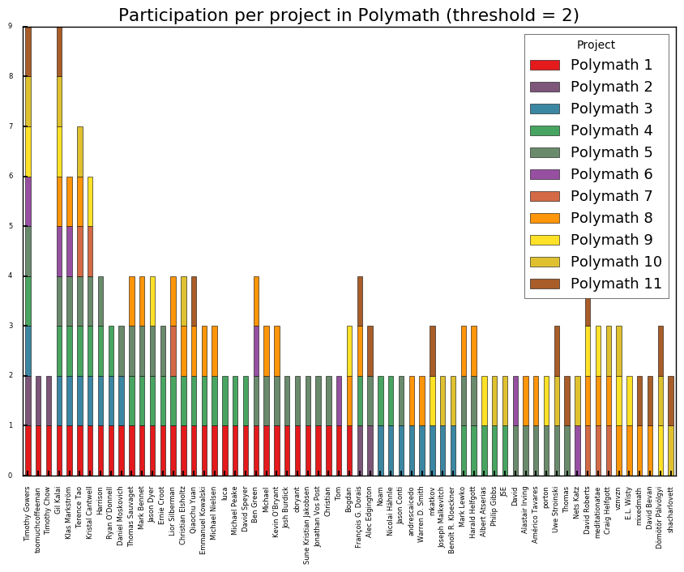

```python
author_project, indices, select_2, title = project_participation_evolution(research_only=False)
plot_participation_evolution(author_project, indices, select_2, title)
```

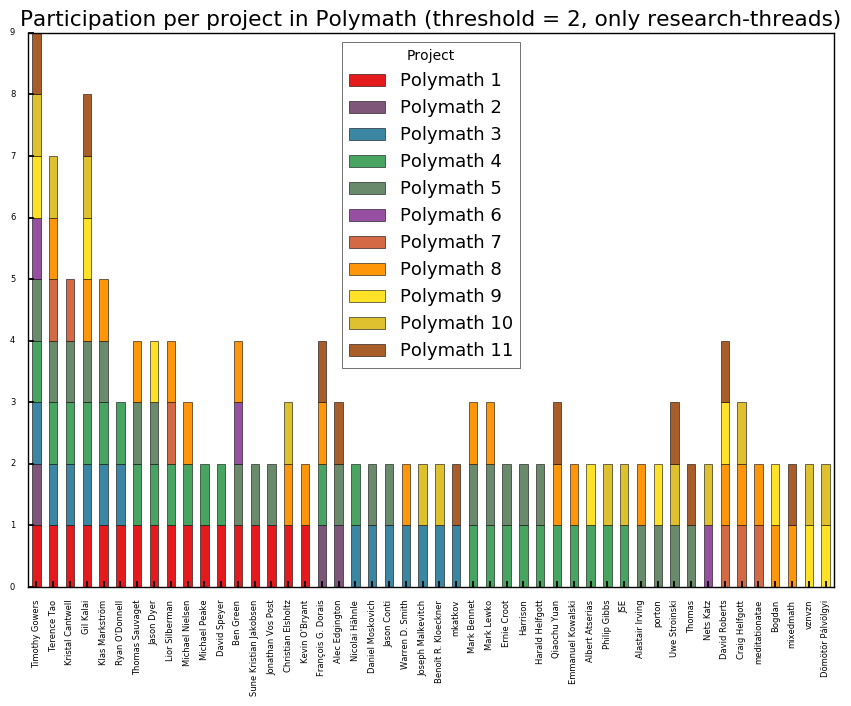

```python
r_author_project, r_indices, r_select_2, title = project_participation_evolution(research_only=True)
plot_participation_evolution(r_author_project, r_indices, r_select_2, title)
```

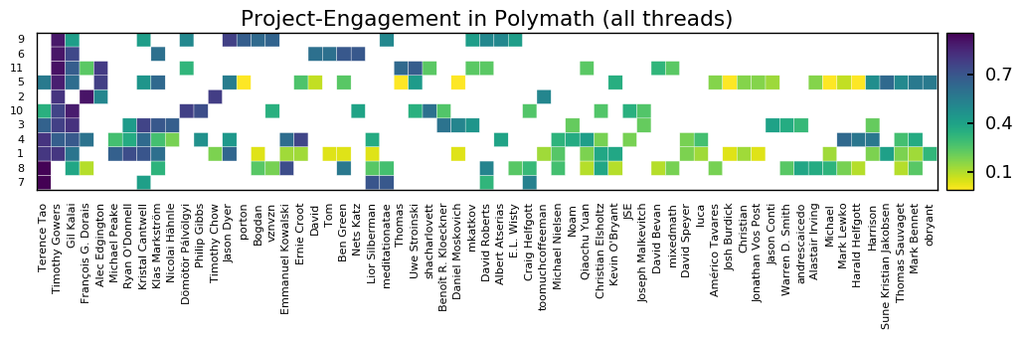

```python
authors_2 = sorted([author for author, bool in select_2.items() if bool])
plot_heatmap(*general_heatmap(authors=authors_2,
                              thread_level=False,
                              binary=False,
                              scale_data=True),
             log=True)
```

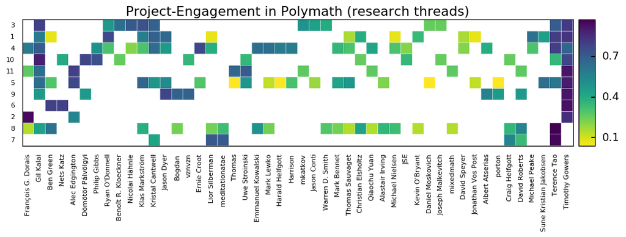

```python
r_authors_2 = sorted([author for author, bool in r_select_2.items() if bool])
plot_heatmap(*general_heatmap(authors=r_authors_2, thread_level=False, binary=False, thread_type='research threads', scale_data=True),
            log=True)
```

- **Global Leaders (3):** Terence Tao, Timothy Gowers, Gil Kalai
- **Local Leaders (2):** François G. Dorais, Alex Edgington
- **Core-participants (18/19):** Peake -> Silberman
- **Periphery (40/39):** meditationatae -> obryant

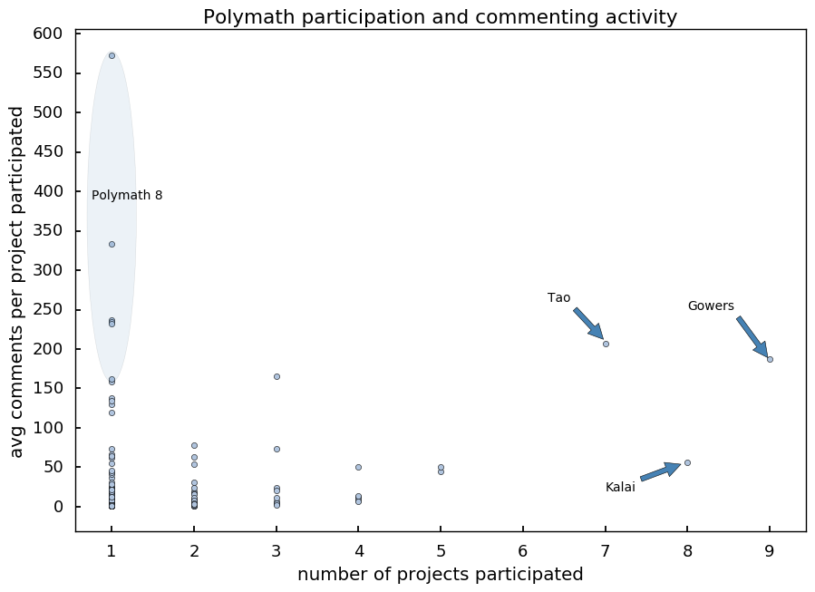

```python
# plotting project-participation as scatter-plot
axes = plt.subplot()
axes.set_xticks(range(11));
axes.set_yticks(range(0, 700, 50));
axes.yaxis.set_ticks_position('left')
axes.xaxis.set_ticks_position('bottom')
axes.annotate('Gowers', xy=(9, 186), xytext=(8, 250),
            arrowprops=dict(facecolor='steelblue', shrink=0.05),
            )
axes.annotate('Kalai', xy=(7.95, 55), xytext=(7, 20),
            arrowprops=dict(facecolor='steelblue', shrink=0.05),
            )
axes.annotate('Tao', xy=(7, 210), xytext=(6.3, 260),
            arrowprops=dict(facecolor='steelblue', shrink=0.05),
            )
e = mpl.patches.Ellipse(xy=(1,368), width=.6, height=420, angle=0)
e.set_alpha(.1)
e.set_facecolor('steelblue')
axes.add_artist(e)
axes.annotate('Polymath 8', xy=(1.2, 400), xytext=(.75, 390))
df.plot(kind='scatter', x='number of projects participated', y='avg comments per project participated',
            color= 'lightsteelblue', ax=axes, title="Polymath participation and commenting activity");
```

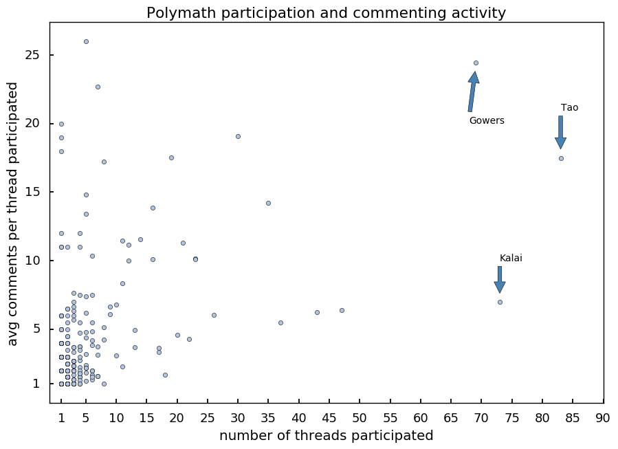

```python
# plotting thread-participation as scatter-plot
axes = plt.subplot()
axes.set_xticks([1] + list(range(5,110,5)));
axes.set_yticks([1]+ list(range(5, 30, 5)));
axes.set_xlim(-1, 90);
axes.yaxis.set_ticks_position('left')
axes.xaxis.set_ticks_position('bottom')
axes.annotate('Gowers', xy=(69, 24), xytext=(68, 20),
            arrowprops=dict(facecolor='steelblue', shrink=0.05),
            )
axes.annotate('Kalai', xy=(73, 7.5), xytext=(73, 10),
            arrowprops=dict(facecolor='steelblue', shrink=0.05),
            )
axes.annotate('Tao', xy=(83, 18), xytext=(83, 21),
            arrowprops=dict(facecolor='steelblue', shrink=0.05),
            )
df_threads.plot(kind='scatter', x='number of threads participated', y='avg comments per thread participated',
            ax=axes, color= 'lightsteelblue', title="Polymath participation and commenting activity");
#df_threads.set_index('number of threads participated', inplace=True)
#df_threads.trendline.sort_index(ascending=False).plot(ax=axes);
#plt.gca().invert_xaxis()
```

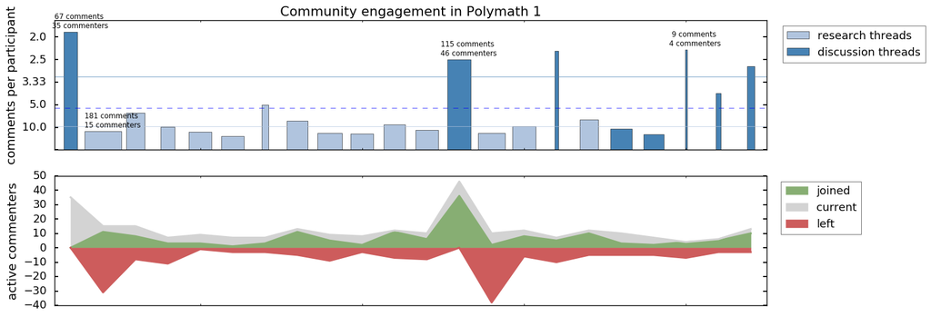

```python
plot_thread_evolution("Polymath 1", compress=160, sel=[1, 2, 13, 20], sharex=True)
```

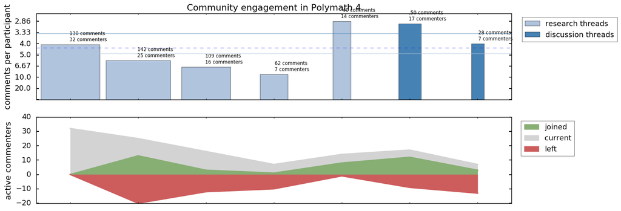

```python
plot_thread_evolution("Polymath 4", compress=150, sel=range(1,8), sharex=True)
```

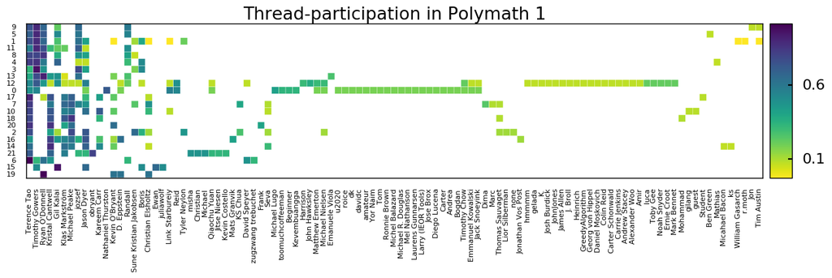

```python
project_heatmap("Polymath 1", cluster_threads=True, method='average', log=True, fontsize=8)
```

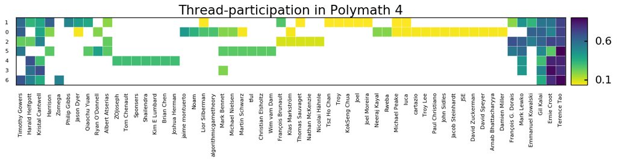

```python
project_heatmap("Polymath 4", cluster_threads=True, method='average', log=True, fontsize=8)
```

# Social-informational patterns

### From a nested discussion to a tree of comments

#### A toy-example

- Blog-post (L0-comment)
  - L1-comment: *timestamp: ..., author: Alice, content: ..., ...*
  - L1-comment: *timestamp: ..., author: Bob, content: ..., ...*
    - L2-comment: *timestamp: ..., author: Alice, content: ..., ...*
    - L2-comment: *timestamp: ..., author: Carol, content: ..., ...*
  - L1-comment: *timestamp: ..., author: Bob, content: ..., ...*
    - L2-sub-comment: *timestamp: ..., author: Alice, content: ..., ...*
      - L3-comment: *timestamp: ..., author: Bob, content: ..., ...*

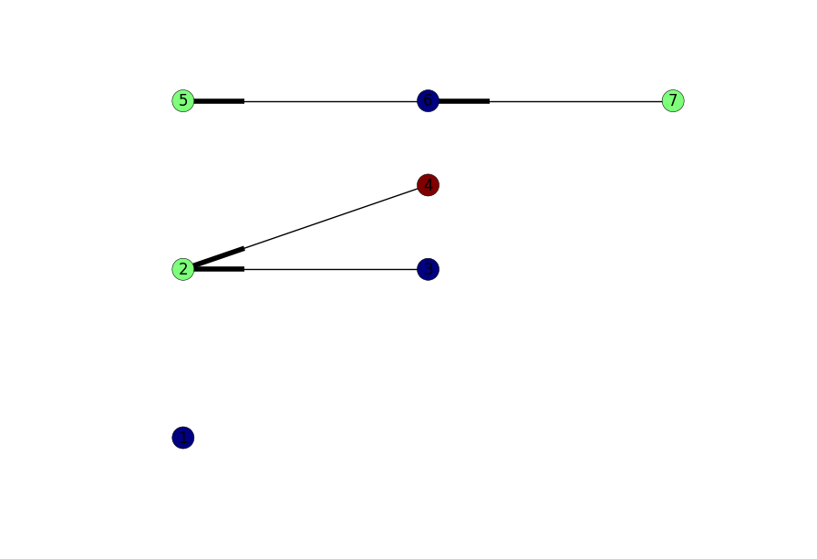

```python
example_graph = nx.DiGraph()
example_graph.add_nodes_from([1,2,3,4,5,6,7])
example_graph.add_edges_from([(3,2), (4,2), (6,5), (7,6)])
matplotlib.style.use(SBSTYLE)
nx.draw_networkx(example_graph, pos={1: (0,0), 2: (0,1), 3: (1,1), 4: (1, 1.5), 5: (0, 2), 6: (1, 2), 7: (2,2)},
                 node_list=[1,2,3,4,5,6,7],
                node_color=[1, 2, 1, 3, 2, 1,2])
limits=plt.axis("off")
```

### To an interaction-network

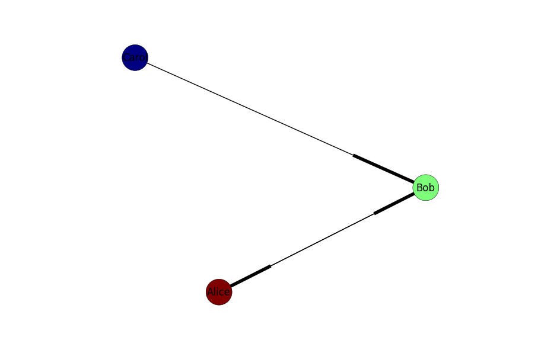

```python
example_graph2 = nx.DiGraph()
example_graph2.add_nodes_from(['Alice', 'Bob', 'Carol'])
example_graph2.add_weighted_edges_from([('Alice', 'Bob', 2), ('Bob', 'Alice', 1), ('Carol', 'Bob', 1)])
matplotlib.style.use(SBSTYLE)
nx.draw_networkx(example_graph2, node_list=['Alice', 'Bob', 'Carol'], node_color=[1,3,2], node_size=1000)
limits=plt.axis("off")
```

### And a co-location network

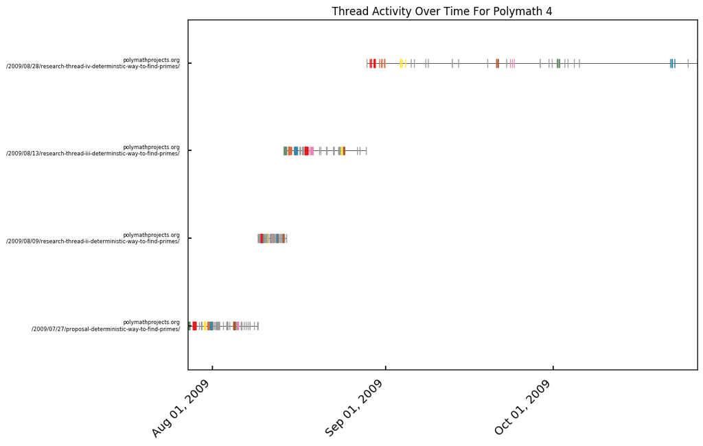

```python
plot_activity_thread("Polymath 4", stage=2, thread_type="research threads")
```

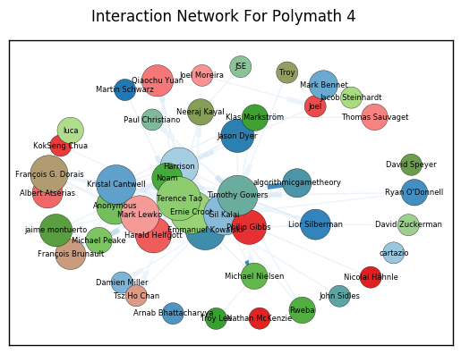

```python
draw_network("Polymath 4", 'interaction', stage=2, reset=True)
```

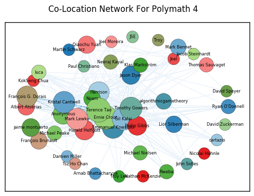

```python
draw_network("Polymath 4", 'cluster', stage=2)
```

# Transparent informational contexts

- Common belief requires public announcements
- Public announcements require transparent informational contexts
- Uncertainty about who is *present* makes informational contexts opaque
- Asynchronous communication leads to uncertainty

## Signalling presence and reducing uncertainty

- Episodes of intense interaction are less opaque
- Being close to the centre of discussion is sufficient for common knowledge about who is close to the centre of discussion
- This allows one to maintain a common ground within the sub-group close to the centre of discussion

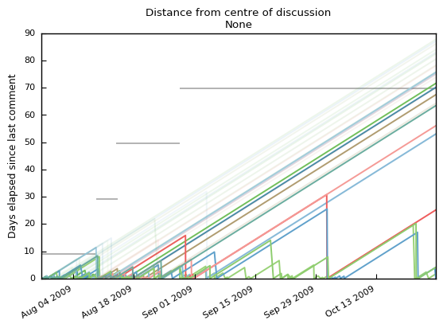

```python
plot_distance_from_centre("Polymath 4", stage=2)
```

# The role of leading figures

- Blog-posts as public announcements
- Always close to the centre of discussion
- Because presence in the centre of discussion is commonly known, the availability of leading figures is commonly known as well
- Trust in central figures and common knowledge of their availability ensures successful aggregation, understood as further pursuing what seems promising and abandoning likely dead-ends.

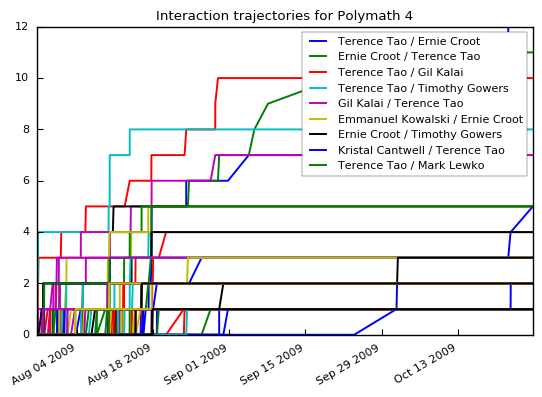

```python
plot_interaction_trajectories("Polymath 4", stage=2, l_thresh=9)
```

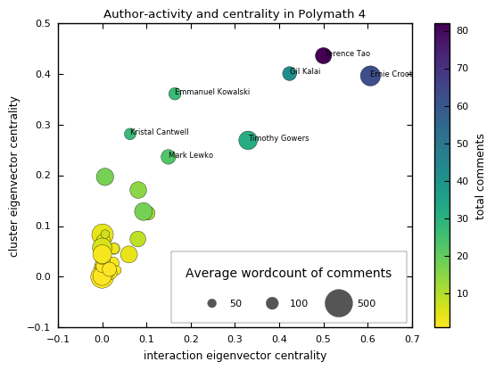

```python
plot_scatter_authors("Polymath 4", stage=2, thresh=20, measure="eigenvector centrality")
```

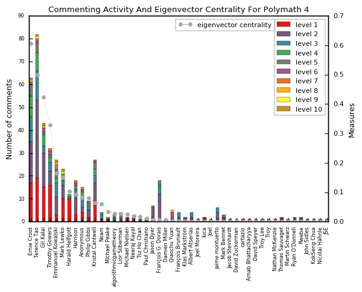

```python
plot_activity_degree("Polymath 4", measures=['eigenvector centrality'], stage=2)
```

## Concluding remarks

- Polymath as a community that was crowdsourced at the early stages of Polymath 1.
- Effective collaboration through group-attitudes.
- Active aggregation by central figures that are commonly known to be available.